# Clusterization

kupryashova

April 4, 2017

```r
library(DESeq2)
library(ggplot2)
library(pheatmap)
library(amap)
library(dbscan)
options(width=120)
```

## Задание 1. Иерархическая кластеризация

```r
counts <- read.csv("GSE89225_Illumina_counts.csv", row.names=1)
conditions <- read.csv("conditions.csv", row.names=1)
mart <- read.table("human_mart.txt", sep="\t", header=1, check.names = F) # не нужен вроде

print(counts[1:6, 1:2]) #экспрессии у разных пациентов(34-1)
```

```
##                 tconv_tumor_patient10 cd177negtreg_tumor_patient10
## ENSG00000000003                   510                          935
## ENSG00000000005                    25                            1
## ENSG00000000419                   613                          818
## ENSG00000000457                   269                          587
## ENSG00000000460                    55                          142
## ENSG00000000938                    36                           69
```

```r
dim(counts)
```

```
## [1] 63677    34
```

```r
head(conditions) # тип рака и клеток у пациентов
```

```
##                                            tissue                               cells
## tconv_tumor_patient10        tissue: breast tumor cell type: Conventional CD4 T cells
## cd177negtreg_tumor_patient10 tissue: breast tumor       cell type: Regulatory T cells
## cd177postreg_tumor_patient10 tissue: breast tumor       cell type: Regulatory T cells
## tconv_tumor_patient1         tissue: breast tumor cell type: Conventional CD4 T cells
## treg_tumor_patient1          tissue: breast tumor       cell type: Regulatory T cells
## tconv_NBP_patient2                    tissue: NBP cell type: Conventional CD4 T cells
```

```r
dim(conditions)
```

```
## [1] 34  2
```

```r
head(mart)  #данные по последовательностям
```

```
##           Gene ID Associated Gene Name Gene type EntrezGene ID
## 1 ENSG00000252303            RNU6-280P     snRNA            NA
## 2 ENSG00000281771                Y_RNA  misc_RNA            NA
## 3 ENSG00000281256         RP11-222G7.2   lincRNA            NA
## 4 ENSG00000283272      Clostridiales-1      sRNA            NA
## 5 ENSG00000280864        RP11-654C22.2   lincRNA            NA
## 6 ENSG00000280792        RP11-315F22.1   lincRNA            NA
```

```r
dim(mart)
```

```
## [1] 64101     4
```

Возьмем весь датасет с аутлаером Создадим DeseqDataSet объект (дизайн не важен) Оставим только 8000 экспрессированых генов Используем rlog(dds) для получения логарифмированных значений экспрессии

```r
dds <- DESeqDataSetFromMatrix(countData = counts,
                              colData = conditions,
                              design = ~ tissue + cells)
dds <- dds[names(sort(rowSums(counts(dds)), decreasing = TRUE)[1:8000]), ] # отсекаем 8000 самых экспр генов

dds <- DESeq(dds)
```

```
## -- replacing outliers and refitting for 192 genes
## -- DESeq argument 'minReplicatesForReplace' = 7
## -- original counts are preserved in counts(dds)
```

```r
#dds <- vst(dds)
dds_log<- rlog(dds) # чем blind отличается от не blind , чем sort отличается от order
# чем принципиально DESeqTransform от DESeqDataSetFromMatrix отличается
counts.norm <- assay(dds_log)
```

Посчитаем корреляции между образцами используя cor (результатом будет матрица размера m×m, где m – количество образцов) Посчитаем матрицу “непохожести” 1 - cor, и dist объект для этой матрицы Сделаем кластеризацию с помощью функции hclust, используя три разных метода “связывания” объектов в группы: average, complete and single

```r
dds_cor <- cor(counts.norm)
dds_cor_rv <- 1 - dds_cor
dds_cor_rv_dist <- dist(dds_cor_rv)

dds_cor_rv_hclust1 <- hclust(dds_cor_rv_dist, method = "average")
dds_cor_rv_hclust2 <- hclust(dds_cor_rv_dist, method = "complete")
dds_cor_rv_hclust3 <- hclust(dds_cor_rv_dist, method = "single")
```

Построим для каждой график с помощью plot

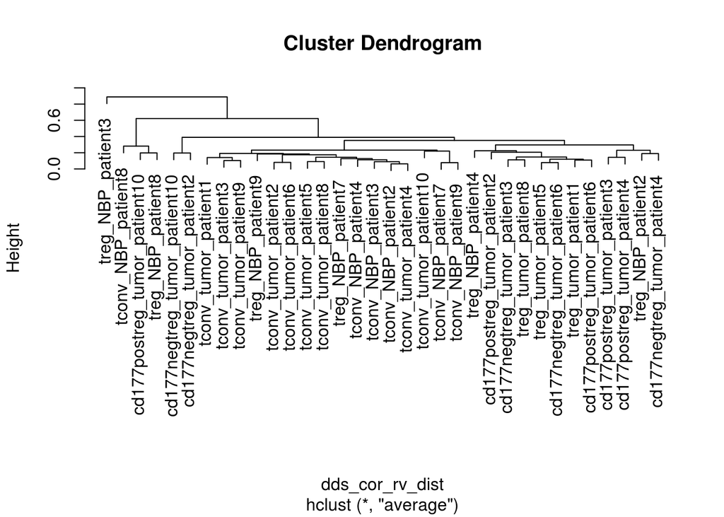

```r
plot(dds_cor_rv_hclust1)
```

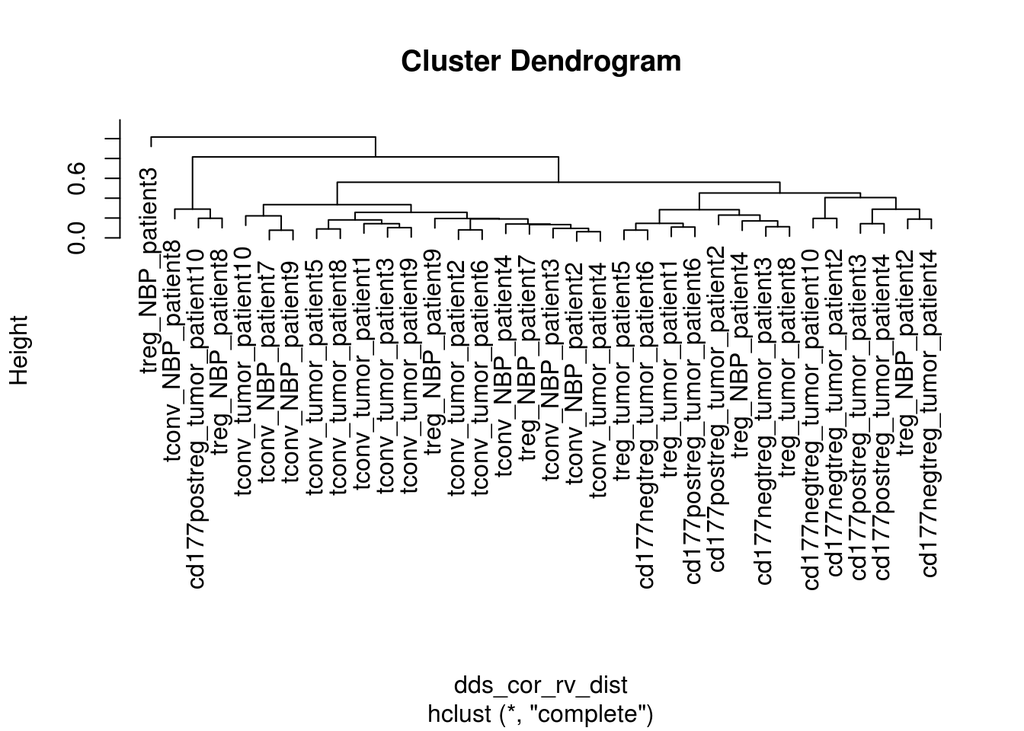

```r
plot(dds_cor_rv_hclust2)
```

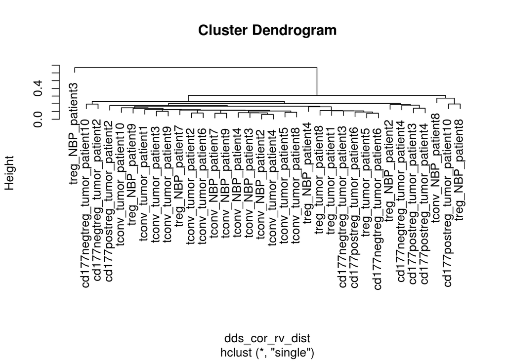

```r
plot(dds_cor_rv_hclust3)
```

## Задание 2. K-means.

Используем K-means для описания паттернов экспрессии

Возьмем весь датасет без аутлаера

```r
#  Removing outlier -  treg_NBP_patient3 (нашли на PCA-plot, aes(...label  = rownames(to_plot),...) + geom_label())
counts$treg_NBP_patient3 <- NULL
conditions <- conditions[-which(rownames(conditions) == 'treg_NBP_patient3'),]
```

Создадим DeseqDataSet объект (дизайн не важен) Оставим только 8000 экспрессированных генов Используем rlog(dds) для получения логарифмированных значений экспрессии

```r
dds2 <- DESeqDataSetFromMatrix(countData = counts,
                              colData = conditions,
                              design = ~ tissue + cells)
dds2 <- dds2[names(sort(rowSums(counts(dds2)), decreasing = TRUE)[1:8000]), ] # отсекаем 8000 самых экспр генов

dds2 <- DESeq(dds2)
```

```
## -- replacing outliers and refitting for 82 genes
## -- DESeq argument 'minReplicatesForReplace' = 7
## -- original counts are preserved in counts(dds)
```

```r
#dds2 <- vst(dds2)
dds2_log<- rlog(dds2) # чем blind отличается от не blind , чем sort отличается от order
# чем принципиально DESeqTransform от DESeqDataSetFromMatrix отличается
counts.norm2 <- assay(dds2_log)
```

Используем функцию Kmeans из пакета amap с методом “correlation”, c количеством кластеров равным 6. (Вы можете выбрать своё количество кластеров), и максимальным количеством итераций равным 20000 После этого вы можете достать соотвествие каждого гена кластеру с помощью элемента листа с названием “cluster”

```r
clustering <- Kmeans(counts.norm2, 6, method="correlation", iter.max=20000)
head(clustering$cluster)
```

```
## ENSG00000166710 ENSG00000210082 ENSG00000251562 ENSG00000075624 ENSG00000198804 ENSG00000198938
##               2               4               3               2               5               5
```

После этого от вас потребуется эту кластеризацию изобразить на хитмапе: гены должны быть отсортированы по кластерам, а столбцы сначала по клеткам, а затем по тканям.

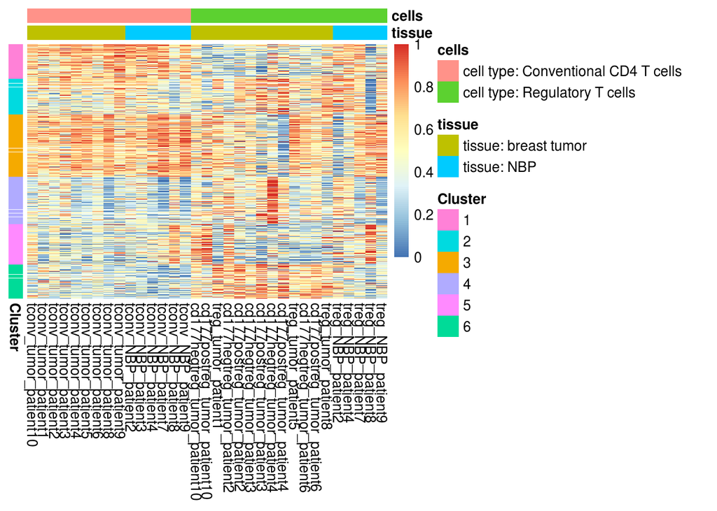

```r
counts.norm2_sorted <- counts.norm2[names(sort(clustering$cluster)), ] # по кластерам
conditions_sorted <- conditions[order(conditions$cells,conditions$tissue),] # по клеткам и тканям
counts.norm2_sorted_all <- counts.norm2_sorted[ , rownames(conditions_sorted)]

ann_row <- data.frame(row.names = names(clustering$cluster), Cluster = as.factor(clustering$cluster))
to_visualise <- t(apply(counts.norm2_sorted_all, 1, function(r) {
  (r - min(r)) / (max(r) - min(r))
}))
pheatmap(to_visualise,
         show_rownames = F, cluster_rows = F,
         cluster_cols=F,
         annotation_col = conditions, annotation_row = ann_row) # откуда на моем графике белые полосы
```

## Задание 3. Density-based algorithms

```r
library(dbscan)
ta <- read.csv(file = 'projection.csv')

str(ta)
```

```
## 'data.frame':    8391 obs. of  3 variables:
##  $ Barcode: Factor w/ 8391 levels "AAACCTGAGCATCATC-1",..: 1 2 3 4 5 6 7 8 9 10 ...
##  $ TSNE.1 : num  16.57 -12.41 8.01 17.36 -33.34 ...
##  $ TSNE.2 : num  -36.03 -24.87 36.19 -8.07 -3.96 ...
```

```r
head(ta)
```

```
##              Barcode     TSNE.1     TSNE.2
## 1 AAACCTGAGCATCATC-1  16.571529 -36.026708
## 2 AAACCTGAGCTAACTC-1 -12.413024 -24.869545
## 3 AAACCTGAGCTAGTGG-1   8.013316  36.188841
## 4 AAACCTGCACATTAGC-1  17.364902  -8.065572
## 5 AAACCTGCACTGTTAG-1 -33.341531  -3.960857
## 6 AAACCTGCATAGTAAG-1 -30.979716 -16.028358
```

```r
ta$scan <- factor(dbscan(ta[2:3], 2, minPts = 1)$cluster)
str(ta)
```

```
## 'data.frame':    8391 obs. of  4 variables:
##  $ Barcode: Factor w/ 8391 levels "AAACCTGAGCATCATC-1",..: 1 2 3 4 5 6 7 8 9 10 ...
##  $ TSNE.1 : num  16.57 -12.41 8.01 17.36 -33.34 ...
##  $ TSNE.2 : num  -36.03 -24.87 36.19 -8.07 -3.96 ...
##  $ scan   : Factor w/ 12 levels "1","2","3","4",..: 1 2 3 3 2 2 3 3 2 3 ...
```

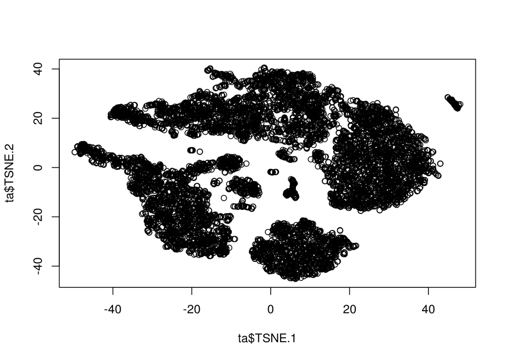

```r
plot(ta$TSNE.1,ta$TSNE.2)
```

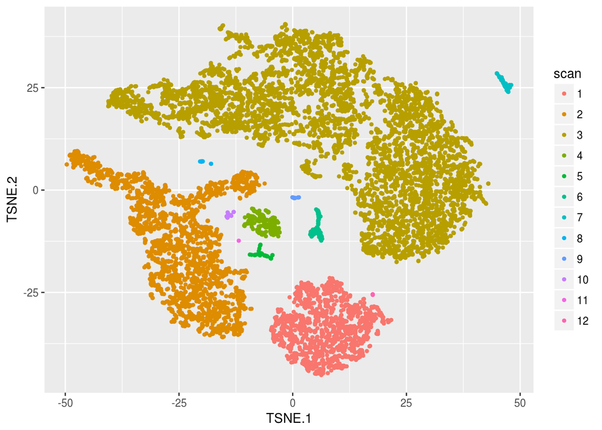

```r
ggplot(data = ta, aes(x=TSNE.1,y=TSNE.2, color=scan))+
  geom_point(size=1)
```